# course assignment Case 2 (Predicting Market to Book Ratio - MTB)

# With Winsorizing done for the 2017 data, I can, then run the boxplot again to visualize how Winsorizing have reduced the effect of outliers on our dataset:

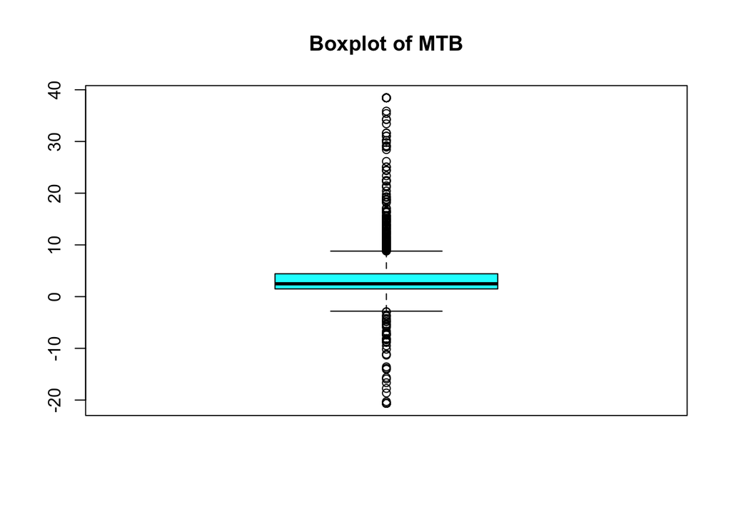

```r
boxplot(winsorized_data2017$MTB, main = "Boxplot of MTB", col = "cyan")
```

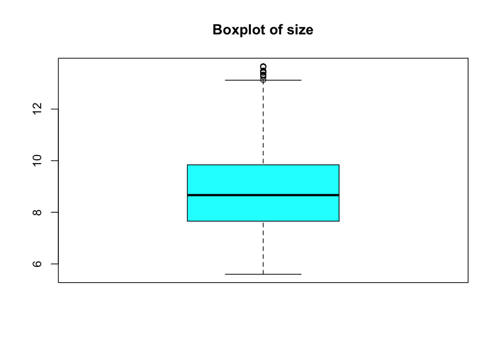

```r
boxplot(winsorized_data2017$size, main = "Boxplot of size", col = "cyan")
```

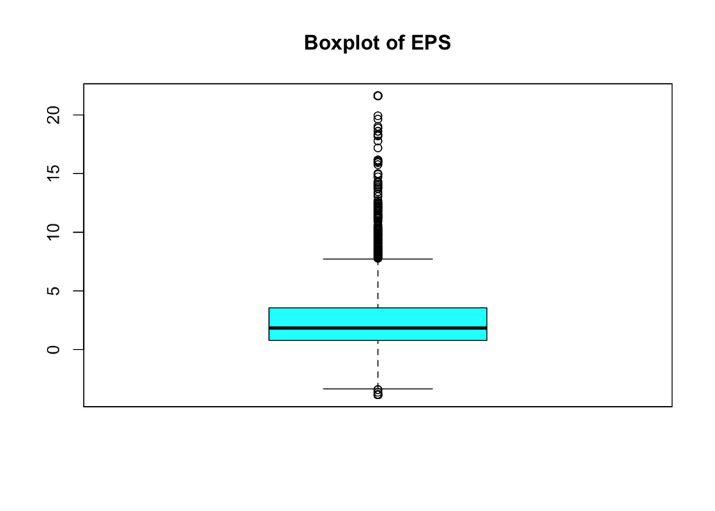

```r
boxplot(winsorized_data2017$EPS, main = "Boxplot of EPS", col = "cyan")
```

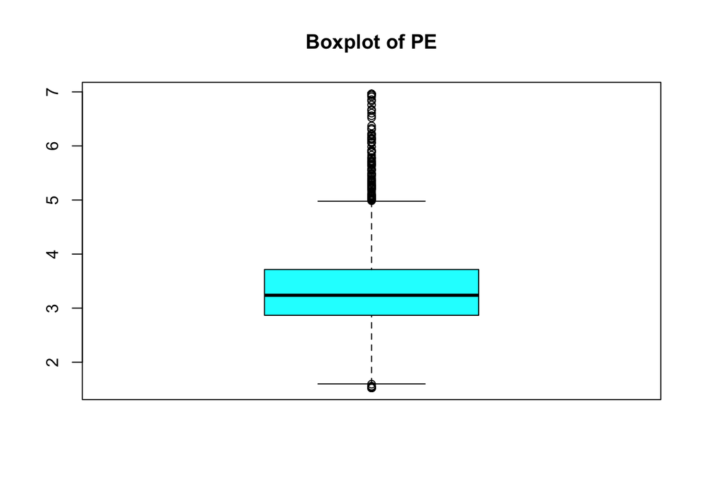

```r
boxplot(winsorized_data2017$PE, main = "Boxplot of PE", col = "cyan")
```

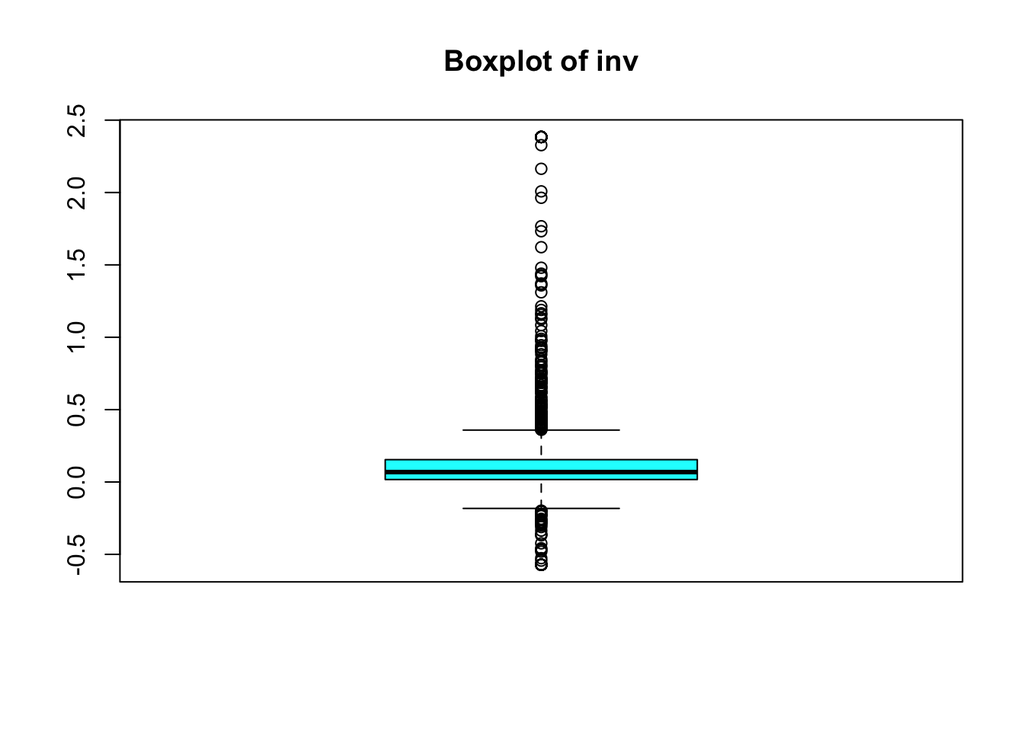

```r
boxplot(winsorized_data2017$inv, main = "Boxplot of inv", col = "cyan")
```

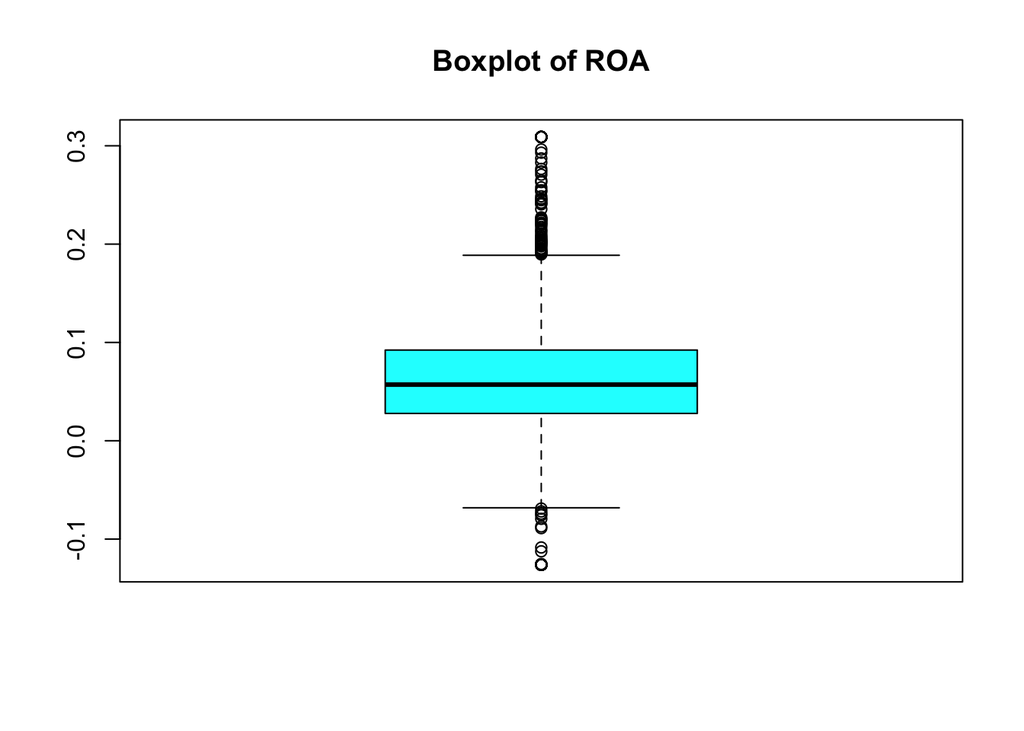

```r
boxplot(winsorized_data2017$ROA, main = "Boxplot of ROA", col = "cyan")
```

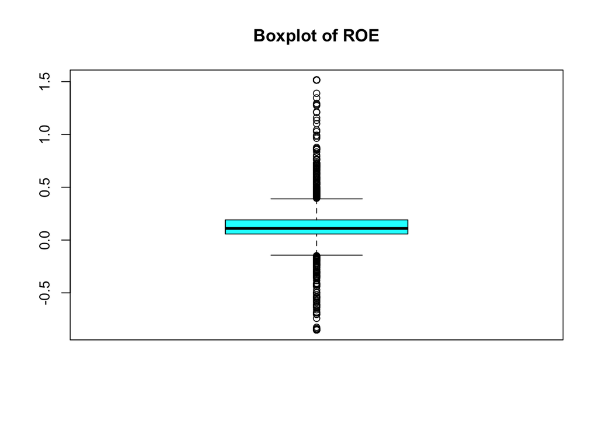

```r
boxplot(winsorized_data2017$ROE, main = "Boxplot of ROE", col = "cyan")
```

# We can plainly observe from the newly constructed boxplot that there have been significant advancements in the reduction of outliers for the 2017 data. In the previously constructed boxplots, the variables contained a large number of data points that were distant from the upper and lower borders, or the whiskers. Using the winsorizing method to eliminate the extreme outliers, our boxplot has been improved overall for all variables. demonstrated by the data’s closer distance from the borders and a clearer IQR. Of course, certain data points in the boxplot are still regarded as outliers, as you may have seen, but this is because the boxplots employed a different technique to identify outliers than the Winsorizing method. Nevertheless, the boxplot technique effectively demonstrated how well were handled the outliers in the data by applying the Winsorizing technique.

```r
summary(winsorized_data2017)
```

```
##       MTB               size             EPS                PE
##  Min.   :-20.629   Min.   : 5.599   Min.   :-3.8577   Min.   :1.526
##  1st Qu.:  1.489   1st Qu.: 7.655   1st Qu.: 0.7767   1st Qu.:2.867
##  Median :  2.487   Median : 8.667   Median : 1.8326   Median :3.238
##  Mean   :  3.703   Mean   : 8.838   Mean   : 2.7365   Mean   :3.385
##  3rd Qu.:  4.418   3rd Qu.: 9.841   3rd Qu.: 3.5540   3rd Qu.:3.714
##  Max.   : 38.444   Max.   :13.649   Max.   :21.6359   Max.   :6.959
##       inv                ROA                ROE               fyear
##  Min.   :-0.57187   Min.   :-0.12613   Min.   :-0.85081   Min.   :2017
##  1st Qu.: 0.01708   1st Qu.: 0.02785   1st Qu.: 0.05723   1st Qu.:2017
##  Median : 0.06857   Median : 0.05710   Median : 0.10974   Median :2017
##  Mean   : 0.13248   Mean   : 0.06517   Mean   : 0.13608   Mean   :2017
##  3rd Qu.: 0.15444   3rd Qu.: 0.09221   3rd Qu.: 0.19072   3rd Qu.:2017
##  Max.   : 2.38349   Max.   : 0.30895   Max.   : 1.51533   Max.   :2017
##   market_value
##  Min.   :  1000
##  1st Qu.:  2239
##  Median :  5049
##  Mean   : 19126
##  3rd Qu.: 14776
##  Max.   :867507
```

# This is the new summry of the data after usingg the winsorizing method, and it is very noticable in the maximum and minimum values of the variables, since now most of them are quite lower/higher and closer to the median.

# Throughout the data cleaming process, there have been removed 214 missng values that were all located in the PE variable. For outliers however, they were not removed but instead were replaced using the Winsorizing method, which replaces values that is above or below the 99% confidence interval with the values at the 99% confidence interval. In the end, the data left us with 2126 observations.

### Consider a linear model for MTB for the year 2017. Use the estimated model with data for 2018 as a test sample. Does the model perform as expected?

# Before creating the linear model, we need to use either ROA or ROE because those two have quite high correlations and cause multicollinearity in the model, which is why in this case we are going to use ROA, annd then create another model with ROE.

```r
model_using_ROA <- lm(MTB ~ ROA + size + inv + PE, data = winsorized_data2017)
summary(model_using_ROA)
```

```
##
## Call:
## lm(formula = MTB ~ ROA + size + inv + PE, data = winsorized_data2017)
##
## Residuals:
##     Min      1Q  Median      3Q     Max
## -29.934  -1.570  -0.599   0.595  35.184
##
## Coefficients:
##             Estimate Std. Error t value Pr(>|t|)
## (Intercept) -0.15672    1.16582  -0.134   0.8931
## ROA         18.65889    2.31010   8.077 1.10e-15 ***
## size        -0.22145    0.08719  -2.540   0.0112 *
## inv          0.09816    0.41301   0.238   0.8122
## PE           1.35545    0.16446   8.242 2.94e-16 ***
## ---
## Signif. codes:  0 '***' 0.001 '**' 0.01 '*' 0.05 '.' 0.1 ' ' 1
##
## Residual standard error: 5.992 on 2121 degrees of freedom
## Multiple R-squared:  0.07147,    Adjusted R-squared:  0.06971
## F-statistic: 40.81 on 4 and 2121 DF,  p-value: < 2.2e-16
```

# At first glance, this linear regression is not performing quite well. The p-value for the intercept would be above 0.05, so it would not be statistically significant. This means that the baseline Market-to-Book ratio—when all predictors are zero—is not different from zero in any statistically significant way. The overall model is statistically significant, but the low value of the Adjusted R-squared of 6.9% reflects that it only explains a small part of the variability in Market-to-Book ratio. This means that some other explanation of MTB exists, which this model fails to capture. In addition, from this regression output, predictors identified to be significant for MTB will be ROA and PE, while size also plays a role.

```r
test_data <- main_data %>%
  filter(fyear == 2018, market_value > 1000) %>%
  select(PE, size, inv, ROA, ROE, MTB) %>%
  na.omit(PE)

summary(test_data)
```

```
##        PE               size              inv                ROA
##  Min.   :-0.7857   Min.   : 0.4849   Min.   :-3.29070   Min.   :-0.79017
##  1st Qu.: 2.5786   1st Qu.: 7.7635   1st Qu.:-0.02426   1st Qu.: 0.02695
##  Median : 3.0290   Median : 8.7994   Median : 0.02987   Median : 0.05840
##  Mean   : 3.1950   Mean   : 8.9473   Mean   : 0.11117   Mean   : 0.06847
##  3rd Qu.: 3.5769   3rd Qu.: 9.9558   3rd Qu.: 0.11404   3rd Qu.: 0.09800
##  Max.   :11.1222   Max.   :15.0447   Max.   : 7.09008   Max.   : 1.39910
##       ROE                  MTB
##  Min.   :-104.04348   Min.   :-3251.904
##  1st Qu.:   0.05522   1st Qu.:    1.186
##  Median :   0.11520   Median :    2.023
##  Mean   :   0.05242   Mean   :    0.247
##  3rd Qu.:   0.19500   3rd Qu.:    3.769
##  Max.   :  30.85546   Max.   : 1470.213
```

# Here I am creating the test data for the year 2018, and in addition I am again filtering values above 1000 for market value and omitting the missing values in PE. After this I am going to winsorize the outliers and then proceed to use it as a test data.

```r
winsorized_data2018 <- winsorizer(test_data, c("size", "inv", "ROA", "ROE", "MTB"))
summary(winsorized_data2018)
```

```
##        PE               size             inv                ROA
##  Min.   :-0.7857   Min.   : 5.699   Min.   :-0.39924   Min.   :-0.15062
##  1st Qu.: 2.5786   1st Qu.: 7.764   1st Qu.:-0.02426   1st Qu.: 0.02695
##  Median : 3.0290   Median : 8.799   Median : 0.02987   Median : 0.05840
##  Mean   : 3.1950   Mean   : 8.951   Mean   : 0.09985   Mean   : 0.06763
##  3rd Qu.: 3.5769   3rd Qu.: 9.956   3rd Qu.: 0.11404   3rd Qu.: 0.09800
##  Max.   :11.1222   Max.   :13.709   Max.   : 2.09338   Max.   : 0.33443
##       ROE                MTB
##  Min.   :-1.23631   Min.   :-16.036
##  1st Qu.: 0.05522   1st Qu.:  1.186
##  Median : 0.11520   Median :  2.023
##  Mean   : 0.12918   Mean   :  3.106
##  3rd Qu.: 0.19500   3rd Qu.:  3.769
##  Max.   : 1.55405   Max.   : 33.739
```

```r
library(caret)

ROA_regression_prediction <- predict(model_using_ROA, newdata = winsorized_data2018)

mseROA <-mean((winsorized_data2018$MTB - ROA_regression_prediction)^2)
rmseROA <- sqrt(mseROA)
maeROA <- mean(abs(winsorized_data2018$MTB - ROA_regression_prediction))
rsquaredROA <- caret::R2(ROA_regression_prediction, winsorized_data2018$MTB)

print(paste("Mean Squared Error (MSE):", mseROA))
```

```
## [1] "Mean Squared Error (MSE): 26.245267506574"
```

```r
print(paste("Root Mean Squared Error (RMSE):", rmseROA))
```

```
## [1] "Root Mean Squared Error (RMSE): 5.12301351809402"
```

```r
print(paste("Mean Absolute Error (MAE):", maeROA))
```

```
## [1] "Mean Absolute Error (MAE): 2.56036905614764"
```

```r
print(paste("R-squared:", rsquaredROA))
```

```
## [1] "R-squared: 0.0881104941563939"
```